# Analyzing FBD parameters

2022-04-08

This vignette explains how to extract FBD (fossilized birth-death) parameters (*net diversification*, *relative extinction (turnover)*, and *relative fossilization*) estimated from relaxed clock Bayesian inference analyses produced by the program [Mr. Bayes](https://nbisweden.github.io/MrBayes/), as used in Simões and Pierce (2021).

## FBD Parameters Statistics and Plots

Extract evolutionary rate summary statistics from each node from a Bayesian clock (time-calibrate) summary tree produced by Mr. Bayes, store them in a data frame, produce summary tables, and plots:

Open the **EvoPhylo** package

```r
library(EvoPhylo)
library(openxlsx)
```

### 1. Import combined log file from all runs.

This is produced by using `import_log`. Alternatively, users can also use **LogCombiner** from the [BEAST2](https://www.beast2.org/beagle-beast-2-in-cluster/index.html) software package. Table is automatically reshaped from wide to long.

```r
## Import all log (.p) files from all runs and combine them, with burn-in = 25% and downsampling to 2.5k trees in each log file
Comb_posterior3p <- import_log("E:/Git/EvoPhylo/_dev/Examples/MultiClockTree/LogFiles3p", burnin = 0.25, downsample = 2500)


##### OR

##(NOT RUN)
## Import combined log file from all runs (if available)

#Comb_posterior3p <- read.table("E:/Git/EvoPhylo/_dev/Examples/MultiClockTree/3p_CombLog(4runs).p", header = TRUE)

## Reshape imported combined log file from wide to long with FBD_reshape
## (reshaping is done automatically when using the import_log function)

#FBD_reshape(Comb_posterior3p)
```

### 2. Summarize FBD parameters by time bin

Summer statistics for each FBD parameter by time bin can be quickly summarized using `FBD_summary`:

```r
## Summarize parameters by time bin and analysis
t3.1<- FBD_summary(Comb_posterior3p, digits = 2)

kableExtra::kbl(t3.1, caption = "FBD parameters by time bin") |>
  kableExtra::kable_styling(font_size = 15, full_width = FALSE, bootstrap_options = "striped", "condensed")
```

FBD parameters by time bin

| parameter | Time_bin | n | mean | sd | min | Q1 | median | Q3 | max |
| --- | --- | --- | --- | --- | --- | --- | --- | --- | --- |
| net_speciation | 1 | 2500 | 0.04 | 0.02 | 0.00 | 0.03 | 0.04 | 0.06 | 0.12 |
| net_speciation | 2 | 2500 | 0.03 | 0.02 | 0.00 | 0.02 | 0.03 | 0.04 | 0.13 |
| net_speciation | 3 | 2500 | 0.02 | 0.01 | 0.00 | 0.01 | 0.02 | 0.03 | 0.09 |
| net_speciation | 4 | 2500 | 0.05 | 0.02 | 0.00 | 0.03 | 0.05 | 0.06 | 0.11 |
| relative_extinction | 1 | 2500 | 0.79 | 0.15 | 0.12 | 0.72 | 0.82 | 0.90 | 1.00 |
| relative_extinction | 2 | 2500 | 0.92 | 0.05 | 0.57 | 0.90 | 0.93 | 0.96 | 1.00 |
| relative_extinction | 3 | 2500 | 0.95 | 0.05 | 0.40 | 0.93 | 0.96 | 0.98 | 1.00 |
| relative_extinction | 4 | 2500 | 0.04 | 0.10 | 0.00 | 0.00 | 0.00 | 0.01 | 0.82 |
| relative_fossilization | 1 | 2500 | 0.04 | 0.05 | 0.00 | 0.01 | 0.02 | 0.05 | 0.58 |
| relative_fossilization | 2 | 2500 | 0.07 | 0.04 | 0.00 | 0.04 | 0.06 | 0.09 | 0.45 |
| relative_fossilization | 3 | 2500 | 0.01 | 0.02 | 0.00 | 0.00 | 0.01 | 0.02 | 0.30 |
| relative_fossilization | 4 | 2500 | 0.04 | 0.11 | 0.00 | 0.00 | 0.00 | 0.02 | 0.93 |

```r
## Export the table
write.csv(t3.1, file="FBD_summary.csv")
```

### 3. Plot the distribution of each FBD parameter

Each of (or all) FBD parameter distributions can be plotted by time bin using various plotting alternatives with `FBD_dens_plot`:

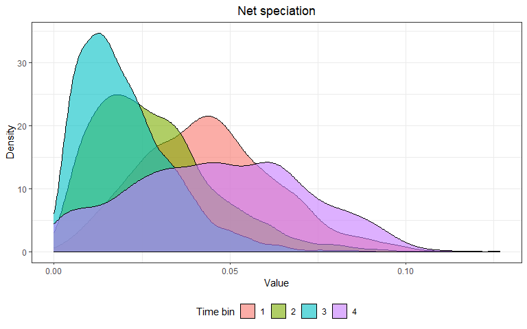

```r
## Plot distribution of the desired FBD parameter by time bin with kernel density plot
FBD_dens_plot(Comb_posterior3p, parameter = "net_speciation", type = "density", stack = FALSE)
```

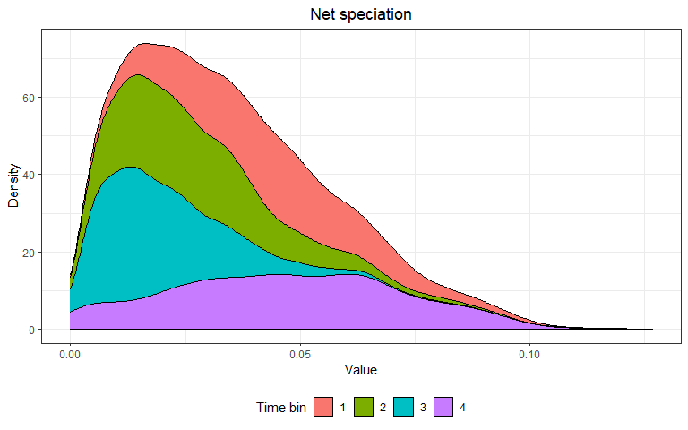

```r
## Plot distribution of the desired FBD parameter by time bin with stacked kernel density plot
FBD_dens_plot(Comb_posterior3p, parameter = "net_speciation", type = "density", stack = TRUE)
```

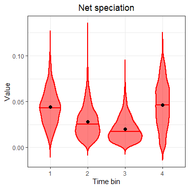

```r
## Plot distribution of the desired FBD parameter by time bin with a violin plot
FBD_dens_plot(Comb_posterior3p, parameter = "net_speciation", type = "violin", stack = FALSE, color = "red")
```

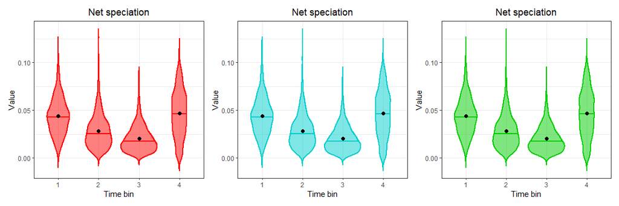

```r
## Plot distribution of all FBD parameter by time bin with a violin plot
p1<-FBD_dens_plot(Comb_posterior3p, parameter = "net_speciation", type = "violin", stack = FALSE, color = "red")
p2<-FBD_dens_plot(Comb_posterior3p, parameter = "net_speciation", type = "violin", stack = FALSE, color = "cyan3")
p3<-FBD_dens_plot(Comb_posterior3p, parameter = "net_speciation", type = "violin", stack = FALSE, color = "green3")

p1|p2|p3
```

```r
##(NOT RUN)
## Save your plot to your working directory as a PDF
#ggplot2::ggsave    ("Plot_regs.pdf", width=12, height=4)
```

### 4. Test for assumptions

In this step, users can perform tests for normality and homoscedasticity in data distribution for each of the FBD parameters under consideration. The output will determine whether parametric or nonparametric tests will be performed subsequently.

```r
##### Tests for normality and homoscedasticity for each FBD parameter for all time bins

t3.2<- FBD_tests1(Comb_posterior3p)

### Export the output table for all tests
openxlsx::write.xlsx(t3.2, file="FBD_Tests1_Assum.xlsx")

### Plot the output table for each test
## Shapiro-Wilk normality test for each parameter
# Output as separate tables
kableExtra::kbl(t3.2$shapiro, digits=4, align=c('c','c','c','c'),  caption = "Shapiro-Wilk normality test ") |>
  kableExtra::kable_styling(font_size = 12, full_width = FALSE,
                            bootstrap_options = "striped", "condensed")
```

Shapiro-Wilk normality test

|  | parameter | statistic | p-value |
| --- | --- | --- | --- |
| Time bin 1 | net_speciation | 0.9886 | 0 |
| Time bin 2 | net_speciation | 0.9535 | 0 |
| Time bin 3 | net_speciation | 0.9229 | 0 |
| Time bin 4 | net_speciation | 0.9868 | 0 |
| Overall | net_speciation | 0.9574 | 0 |
| Residuals | net_speciation | 0.9885 | 0 |

|  | parameter | statistic | p-value |
| --- | --- | --- | --- |
| Time bin 1 | relative_extinction | 0.8927 | 0 |
| Time bin 2 | relative_extinction | 0.9113 | 0 |
| Time bin 3 | relative_extinction | 0.7738 | 0 |
| Time bin 4 | relative_extinction | 0.3846 | 0 |
| Overall | relative_extinction | 0.7008 | 0 |
| Residuals | relative_extinction | 0.8230 | 0 |

|  | parameter | statistic | p-value |
| --- | --- | --- | --- |
| Time bin 1 | relative_fossilization | 0.6127 | 0 |
| Time bin 2 | relative_fossilization | 0.8783 | 0 |
| Time bin 3 | relative_fossilization | 0.5195 | 0 |
| Time bin 4 | relative_fossilization | 0.4386 | 0 |
| Overall | relative_fossilization | 0.5543 | 0 |
| Residuals | relative_fossilization | 0.5477 | 0 |

```r
# OR as single merged table
t3.2$shapiro$net_speciation$bin <- row.names(t3.2$shapiro$net_speciation)
t3.2$shapiro$relative_extinction$bin <- row.names(t3.2$shapiro$relative_extinction)
t3.2$shapiro$relative_fossilization$bin <- row.names(t3.2$shapiro$relative_fossilization)

k1all <- rbind (t3.2$shapiro$net_speciation, t3.2$shapiro$relative_extinction, t3.2$shapiro$relative_fossilization,
                make.row.names = FALSE)

k1<-kableExtra::kbl(k1all, digits=4, caption = "Shapiro-Wilk normality test ") |>
  kableExtra::kable_styling(font_size = 12, full_width = FALSE, bootstrap_options = "striped", "condensed")
k1
```

Shapiro-Wilk normality test

| parameter | statistic | p-value | bin |
| --- | --- | --- | --- |
| net_speciation | 0.9886 | 0 | Time bin 1 |
| net_speciation | 0.9535 | 0 | Time bin 2 |
| net_speciation | 0.9229 | 0 | Time bin 3 |
| net_speciation | 0.9868 | 0 | Time bin 4 |
| net_speciation | 0.9574 | 0 | Overall |
| net_speciation | 0.9885 | 0 | Residuals |
| relative_extinction | 0.8927 | 0 | Time bin 1 |
| relative_extinction | 0.9113 | 0 | Time bin 2 |
| relative_extinction | 0.7738 | 0 | Time bin 3 |
| relative_extinction | 0.3846 | 0 | Time bin 4 |
| relative_extinction | 0.7008 | 0 | Overall |
| relative_extinction | 0.8230 | 0 | Residuals |
| relative_fossilization | 0.6127 | 0 | Time bin 1 |
| relative_fossilization | 0.8783 | 0 | Time bin 2 |
| relative_fossilization | 0.5195 | 0 | Time bin 3 |
| relative_fossilization | 0.4386 | 0 | Time bin 4 |
| relative_fossilization | 0.5543 | 0 | Overall |
| relative_fossilization | 0.5477 | 0 | Residuals |

```r
## Bartlett's test for homogeneity of variance
k2<-kableExtra::kbl(t3.2$bartlett, caption = "Bartlett's test") |>
  kableExtra::kable_styling(font_size = 12, full_width = FALSE, bootstrap_options = "striped", "condensed")
k2
```

Bartlett’s test

| parameter | statistic | p-value |
| --- | --- | --- |
| net_speciation | 920.2642 | 0 |
| relative_extinction | 4398.8738 | 0 |
| relative_fossilization | 5832.1551 | 0 |

```r
## Fligner-Killeen test for homogeneity of variance
k3<-kableExtra::kbl(t3.2$fligner, caption = "Fligner-Killeen test") |>
  kableExtra::kable_styling(font_size = 12, full_width = FALSE, bootstrap_options = "striped", "condensed")
k3
```

Fligner-Killeen test

| parameter | statistic | p-value |
| --- | --- | --- |
| net_speciation | 915.3596 | 0 |
| relative_extinction | 2942.8290 | 0 |
| relative_fossilization | 1235.5207 | 0 |

Deviations from normality can be displayed graphically using `FBD_normality_plot`:

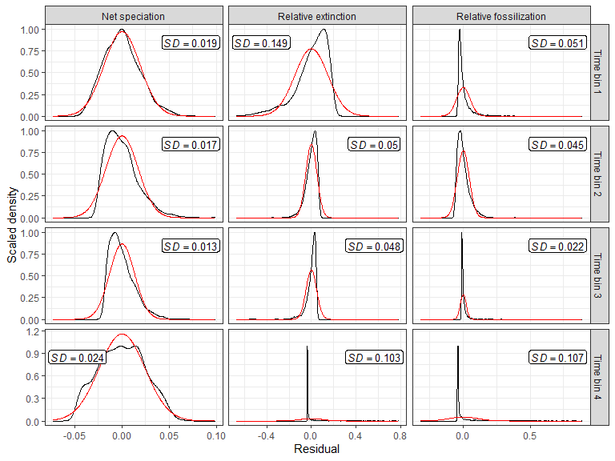

```r
## Visualize deviations from normality and similarity of variances
FBD_normality_plot(Comb_posterior3p)
```

```r
##(NOT RUN)
## Save your plot to your working directory as a PDF
#ggplot2::ggsave    ("Plot_normTests.pdf", width=8, height=6)
```

### 5. Test for significant FBD shifts between time bins

Significant shifts in FBD parameters across time bins can be easily tested using parametric (Student’s t-test) and nonparametric (Mann-Whitney test) pairwise comparisons with `FBD_tests2`. Both are automatically calculated and the preferred pairwise comparison will be chosen by the user depending on the results of the assumption tests **step #4** (above).

```r
##### Test for significant differences between each time bin for each FBD parameter

t3.3<- FBD_tests2(Comb_posterior3p)

### Export the output table for all tests
openxlsx::write.xlsx(t3.3, file="FBD_Tests2_Sign.xlsx")

### Plot the output table for each test
## Pairwise t-tests
# Output as separate tables
kableExtra::kbl(t3.3$t_tests, digits=4, align=c('c','c','c','c'),  caption = "Significant tests ") |>
  kableExtra::kable_styling(font_size = 10, full_width = FALSE,
                            bootstrap_options = "striped", "condensed")
```

Significant tests

| parameter | Time_bin1 | Time_bin2 | n1 | n2 | p-value | p-value adj |
| --- | --- | --- | --- | --- | --- | --- |
| net_speciation | 1 | 2 | 2500 | 2500 | 0 | 0 |
| net_speciation | 1 | 3 | 2500 | 2500 | 0 | 0 |
| net_speciation | 1 | 4 | 2500 | 2500 | 0 | 0 |
| net_speciation | 2 | 3 | 2500 | 2500 | 0 | 0 |
| net_speciation | 2 | 4 | 2500 | 2500 | 0 | 0 |
| net_speciation | 3 | 4 | 2500 | 2500 | 0 | 0 |

| parameter | Time_bin1 | Time_bin2 | n1 | n2 | p-value | p-value adj |
| --- | --- | --- | --- | --- | --- | --- |
| relative_extinction | 1 | 2 | 2500 | 2500 | 0 | 0 |
| relative_extinction | 1 | 3 | 2500 | 2500 | 0 | 0 |
| relative_extinction | 1 | 4 | 2500 | 2500 | 0 | 0 |
| relative_extinction | 2 | 3 | 2500 | 2500 | 0 | 0 |
| relative_extinction | 2 | 4 | 2500 | 2500 | 0 | 0 |
| relative_extinction | 3 | 4 | 2500 | 2500 | 0 | 0 |

| parameter | Time_bin1 | Time_bin2 | n1 | n2 | p-value | p-value adj |
| --- | --- | --- | --- | --- | --- | --- |
| relative_fossilization | 1 | 2 | 2500 | 2500 | 0.0000 | 0.0000 |
| relative_fossilization | 1 | 3 | 2500 | 2500 | 0.0000 | 0.0000 |
| relative_fossilization | 1 | 4 | 2500 | 2500 | 0.2986 | 0.2986 |
| relative_fossilization | 2 | 3 | 2500 | 2500 | 0.0000 | 0.0000 |
| relative_fossilization | 2 | 4 | 2500 | 2500 | 0.0000 | 0.0000 |
| relative_fossilization | 3 | 4 | 2500 | 2500 | 0.0000 | 0.0000 |

```r
# OR as single merged table
k3.3a <- rbind (t3.3$t_tests$net_speciation, t3.3$t_tests$relative_extinction, t3.3$t_tests$relative_fossilization,
                make.row.names = FALSE)

kableExtra::kbl(k3.3a, digits=4, align=c('c','c','c','c'), caption = "Pairwise t-tests") |>
  kableExtra::kable_styling(font_size = 12, full_width = FALSE,
                            bootstrap_options = "striped", "condensed")
```

Pairwise t-tests

| parameter | Time_bin1 | Time_bin2 | n1 | n2 | p-value | p-value adj |
| --- | --- | --- | --- | --- | --- | --- |
| net_speciation | 1 | 2 | 2500 | 2500 | 0.0000 | 0.0000 |
| net_speciation | 1 | 3 | 2500 | 2500 | 0.0000 | 0.0000 |
| net_speciation | 1 | 4 | 2500 | 2500 | 0.0000 | 0.0000 |
| net_speciation | 2 | 3 | 2500 | 2500 | 0.0000 | 0.0000 |
| net_speciation | 2 | 4 | 2500 | 2500 | 0.0000 | 0.0000 |
| net_speciation | 3 | 4 | 2500 | 2500 | 0.0000 | 0.0000 |
| relative_extinction | 1 | 2 | 2500 | 2500 | 0.0000 | 0.0000 |
| relative_extinction | 1 | 3 | 2500 | 2500 | 0.0000 | 0.0000 |
| relative_extinction | 1 | 4 | 2500 | 2500 | 0.0000 | 0.0000 |
| relative_extinction | 2 | 3 | 2500 | 2500 | 0.0000 | 0.0000 |
| relative_extinction | 2 | 4 | 2500 | 2500 | 0.0000 | 0.0000 |
| relative_extinction | 3 | 4 | 2500 | 2500 | 0.0000 | 0.0000 |
| relative_fossilization | 1 | 2 | 2500 | 2500 | 0.0000 | 0.0000 |
| relative_fossilization | 1 | 3 | 2500 | 2500 | 0.0000 | 0.0000 |
| relative_fossilization | 1 | 4 | 2500 | 2500 | 0.2986 | 0.2986 |
| relative_fossilization | 2 | 3 | 2500 | 2500 | 0.0000 | 0.0000 |
| relative_fossilization | 2 | 4 | 2500 | 2500 | 0.0000 | 0.0000 |
| relative_fossilization | 3 | 4 | 2500 | 2500 | 0.0000 | 0.0000 |

```r
## Mann-Whitney tests #Use if Tests in step #4 fail assumptions

# Output as separate tables
kableExtra::kbl(t3.3$mwu_tests, digits=4, align=c('c','c','c','c'), caption = "Mann-Whitney tests") |>
  kableExtra::kable_styling(font_size = 10, full_width = FALSE,
                            bootstrap_options = "striped", "condensed")
```

Mann-Whitney tests

| parameter | Time_bin1 | Time_bin2 | n1 | n2 | p-value | p-value adj |
| --- | --- | --- | --- | --- | --- | --- |
| net_speciation | 1 | 2 | 2500 | 2500 | 0 | 0 |
| net_speciation | 1 | 3 | 2500 | 2500 | 0 | 0 |
| net_speciation | 1 | 4 | 2500 | 2500 | 0 | 0 |
| net_speciation | 2 | 3 | 2500 | 2500 | 0 | 0 |
| net_speciation | 2 | 4 | 2500 | 2500 | 0 | 0 |
| net_speciation | 3 | 4 | 2500 | 2500 | 0 | 0 |

| parameter | Time_bin1 | Time_bin2 | n1 | n2 | p-value | p-value adj |
| --- | --- | --- | --- | --- | --- | --- |
| relative_extinction | 1 | 2 | 2500 | 2500 | 0 | 0 |
| relative_extinction | 1 | 3 | 2500 | 2500 | 0 | 0 |
| relative_extinction | 1 | 4 | 2500 | 2500 | 0 | 0 |
| relative_extinction | 2 | 3 | 2500 | 2500 | 0 | 0 |
| relative_extinction | 2 | 4 | 2500 | 2500 | 0 | 0 |
| relative_extinction | 3 | 4 | 2500 | 2500 | 0 | 0 |

| parameter | Time_bin1 | Time_bin2 | n1 | n2 | p-value | p-value adj |
| --- | --- | --- | --- | --- | --- | --- |
| relative_fossilization | 1 | 2 | 2500 | 2500 | 0 | 0 |
| relative_fossilization | 1 | 3 | 2500 | 2500 | 0 | 0 |
| relative_fossilization | 1 | 4 | 2500 | 2500 | 0 | 0 |
| relative_fossilization | 2 | 3 | 2500 | 2500 | 0 | 0 |
| relative_fossilization | 2 | 4 | 2500 | 2500 | 0 | 0 |
| relative_fossilization | 3 | 4 | 2500 | 2500 | 0 | 0 |

```r
# OR as single merged table
k3.3b <- rbind (t3.3$mwu_tests$net_speciation, t3.3$mwu_tests$relative_extinction, t3.3$mwu_tests$relative_fossilization,
                make.row.names = FALSE)

kableExtra::kbl(k3.3b, digits=4, align=c('c','c','c','c'), caption = "Mann-Whitney tests") |>
  kableExtra::kable_styling(font_size = 12, full_width = FALSE,
                            bootstrap_options = "striped", "condensed")
```

Mann-Whitney tests

| parameter | Time_bin1 | Time_bin2 | n1 | n2 | p-value | p-value adj |
| --- | --- | --- | --- | --- | --- | --- |
| net_speciation | 1 | 2 | 2500 | 2500 | 0 | 0 |
| net_speciation | 1 | 3 | 2500 | 2500 | 0 | 0 |
| net_speciation | 1 | 4 | 2500 | 2500 | 0 | 0 |
| net_speciation | 2 | 3 | 2500 | 2500 | 0 | 0 |
| net_speciation | 2 | 4 | 2500 | 2500 | 0 | 0 |
| net_speciation | 3 | 4 | 2500 | 2500 | 0 | 0 |
| relative_extinction | 1 | 2 | 2500 | 2500 | 0 | 0 |
| relative_extinction | 1 | 3 | 2500 | 2500 | 0 | 0 |
| relative_extinction | 1 | 4 | 2500 | 2500 | 0 | 0 |
| relative_extinction | 2 | 3 | 2500 | 2500 | 0 | 0 |
| relative_extinction | 2 | 4 | 2500 | 2500 | 0 | 0 |
| relative_extinction | 3 | 4 | 2500 | 2500 | 0 | 0 |
| relative_fossilization | 1 | 2 | 2500 | 2500 | 0 | 0 |
| relative_fossilization | 1 | 3 | 2500 | 2500 | 0 | 0 |
| relative_fossilization | 1 | 4 | 2500 | 2500 | 0 | 0 |
| relative_fossilization | 2 | 3 | 2500 | 2500 | 0 | 0 |
| relative_fossilization | 2 | 4 | 2500 | 2500 | 0 | 0 |
| relative_fossilization | 3 | 4 | 2500 | 2500 | 0 | 0 |

Simões, Tiago R., and Stephanie E. Pierce. 2021. “Sustained High Rates of Morphological Evolution During the Rise of Tetrapods.” *Nature Ecology & Evolution* 5 (10): 1403–14. https://doi.org/10.1038/s41559-021-01532-x.